# Cyclistic Capstone Project

Brian Hafner

2024-01-28

# Cyclistic Rides Analysis

## Background of Cyclistic

Cyclistic is a bike-share program in Chicago, established in 2016, with 5,824 bicycles across 692 stations. They offer various pricing plans, categorizing customers into casual riders (using single-ride or full-day passes) and members (holding annual memberships). The company’s financial analysis reveals that annual members generate more profit than casual riders. Therefore, Cyclistic aims to convert casual riders into annual members by analyzing historical bike trip data to understand their needs and preferences.

## Plan of Analysis

I’m using the Ask, Prepare, Process, Analyze, and Deliver framework I learned in the Google Data Analytics Certificate course to guide my analysis.

1. Ask - Define the problem clearly.
2. Prepare - Gather the data, organize it and clean it.
3. Process - Transform the data so I can work with it effectively.
4. Analyze - Identify trends and relationships in the data.
5. Share - Interpret & communicate my findings to key stakeholders.
6. Act - Make data-driven decisions based on my analysis.

## Data Analysis Process Step 1 - Ask

### Business Task

The primary task is to analyze how casual riders and annual members use Cyclistic bikes differently. The goal is to support a marketing strategy aimed at converting casual riders into annual members. This task is based on the belief held by Lily Moreno, the director of marketing, that maximizing the number of annual memberships is key to Cyclistic’s growth.

### Guiding Questions

- How do annual members and casual riders use Cyclistic bikes differently?
- What insights can be drawn from these differences to convert casual riders into annual members?

### Key Stakeholders

- Cyclistic Users: Casual Riders and Annual Members
- Lily Moreno, Director of Marketing
- Cyclistic Marketing Analytics Team
- Cyclistic Executive Team: They will decide whether to approve the recommended marketing program.

### Deliverable

The deliverable is a comprehensive analysis of the differences in bike usage between casual riders and annual members. The analysis will inform a marketing strategy aimed at converting casual riders into annual members. The findings will be shared with the key stakeholders to aid in decision-making.

## Data Analysis Process Step 2 - Prepare

In this section, I will describe the data source, the data organization, the data quality, and the data cleaning process.

### Data Source

- The data I used is from the Divvy Tripdata website: https://divvy-tripdata.s3.amazonaws.com/index.html
- The data consists of 12 csv files, one for each month of 2023, containing information about the bike rides taken by Cyclistic users.
- The data is publicly available and does not have any licensing, privacy, security, or accessibility issues.

### Data Organization

- The data has 13 columns, with the following names and meanings:
  - ride_id: Unique identifier for each ride
  - ended_at: Date and time the ride ended
  - end_station_name: Name of the station where the ride ended
  - start_lng: Longitude of the station where the ride started
  - member_casual: Type of user (annual member or casual rider)
  - rideable_type: Type of bike used for the ride
  - start_station_name: Name of the station where the ride started
  - end_station_id: Unique identifier for the station where the ride ended
  - end_lat: Latitude of the station where the ride ended
  - started_at: Date and time the ride started
  - start_station_id: Unique identifier for the station where the ride started
  - start_lat: Latitude of the station where the ride started
  - end_lng: Longitude of the station where the ride ended
- The data has 5,719,877 rows, representing the rides taken by Cyclistic users in 2023.

### Data Cleaning Steps

#### 1. Load Required Packages

```r
### Load required packages
# List of packages
packages <- c(
   "data.table",
   "stringr",
   "dplyr",
   "ggplot2",
   "lubridate",
   "dplyr",
   "tidyverse",
   "knitr",
   "tibble"
)

# Function to check and install packages
check_and_install <- function(pkg) {
   if (!pkg %in% installed.packages()) {
      install.packages(pkg)
   }
}

# Apply the function to each package
sapply(packages, check_and_install)

# Load the packages
lapply(packages, library, character.only = TRUE)
### End Load Packages
```

#### 2. Open 12 csv files (Jan to Dec 2023) and merge into the “data” dataframe.

```r
## Open 12 csv files (Jan to Dec 2023 and merge into one dataframe called "data")

# Specify the path to the directory
files <- list.files(path = "../data-raw", pattern = ".csv")

temp <- lapply(files, function(x) fread(paste0("../data-raw/", x), sep = ","))
data <- rbindlist(temp)
```

## Data Analysis Process Step 3 - Process

In this section, I will describe the tools used, the data cleaning process, and the data transformation process.

### Tools Used

I chose RStudio for this analysis because it can efficiently handle large datasets.

### Data Cleaning

- I reviewed the data and performed spot checks to ensure its integrity.
- I handled missing values in the dataset by replacing them with the median values of the respective columns.
- I removed irregularities in the data using the is.na() function.

Here’s the R code for the data cleaning process:

```r
# Check the structure of the data
str(data)
```

```
## Classes 'data.table' and 'data.frame':   5719877 obs. of  13 variables:
##  $ ride_id           : chr  "F96D5A74A3E41399" "13CB7EB698CEDB88" "BD88A2E670661CE5" "C90792D034FED968" ...
##  $ rideable_type     : chr  "electric_bike" "classic_bike" "electric_bike" "classic_bike" ...
##  $ started_at        : POSIXct, format: "2023-01-21 20:05:42" "2023-01-10 15:37:36" ...
##  $ ended_at          : POSIXct, format: "2023-01-21 20:16:33" "2023-01-10 15:46:05" ...
##  $ start_station_name: chr  "Lincoln Ave & Fullerton Ave" "Kimbark Ave & 53rd St" "Western Ave & Lunt Ave" "Kimbark Ave & 53rd St" ...
##  $ start_station_id  : chr  "TA1309000058" "TA1309000037" "RP-005" "TA1309000037" ...
##  $ end_station_name  : chr  "Hampden Ct & Diversey Ave" "Greenwood Ave & 47th St" "Valli Produce - Evanston Plaza" "Greenwood Ave & 47th St" ...
##  $ end_station_id    : chr  "202480.0" "TA1308000002" "599" "TA1308000002" ...
##  $ start_lat         : num  41.9 41.8 42 41.8 41.8 ...
##  $ start_lng         : num  -87.6 -87.6 -87.7 -87.6 -87.6 ...
##  $ end_lat           : num  41.9 41.8 42 41.8 41.8 ...
##  $ end_lng           : num  -87.6 -87.6 -87.7 -87.6 -87.6 ...
##  $ member_casual     : chr  "member" "member" "casual" "member" ...
##  - attr(*, ".internal.selfref")=<externalptr>
```

### Data Transformation

- I converted the started_at and ended_at columns from string to date format.
- I created a new column called ride_length by subtracting the started_at column from the ended_at column.
- I created two new columns, day_of_week and month_of_year, to facilitate further analysis.

Here’s the R code for the data transformation process:

```r
# Convert 'started_at' and 'ended_at' from string to date format
data$started_at <- as.POSIXct(data$started_at, format = "%Y-%m-%d %H:%M:%S")
data$ended_at <- as.POSIXct(data$ended_at, format = "%Y-%m-%d %H:%M:%S")

# Create 'ride_length' column
data$ride_length <- as.numeric(difftime(data$ended_at, data$started_at, units = "secs"))

# Create 'day_of_week' column
data$day_of_week <- wday(data$started_at)

# Create 'month_of_year' column
data$month_of_year <- format(data$started_at, "%Y-%m")
```

## Data Analysis Process Step 4 - Analysis

### Key Considerations

- **Data Organization for Analysis**

  I utilized the comprehensive dataset for the year 2023, spanning from January to December. Given the large size of the data, which was beyond Excel’s handling capacity, I opted to process it using RStudio (Desktop Edition) on my Mac. I enriched the dataset by adding `ride_time` and `day_of_week` columns and subsequently saved the modified dataframe, `data`. For comparison of storage efficiency, I stored the data in two formats:

  ```
    - `2023_data_cyclistic.csv` with a size of 1.2 GB
    - `2023_data_cyclistic.RData` with a size of 189.4 MB
  ```

- **Data Formatting Verification**

  I am confident that the data has been formatted correctly. However, I noticed some anomalies: 272 records had the end time preceding the start time, and 997 records had a ride length of 0.

  ```
    - `sum(data$ride_length < 0, na.rm = TRUE)` resulted in 272
    - `sum(data$ride_length == 0, na.rm = TRUE)` resulted in 997
  ```

- **Unexpected Discoveries in the Data**

  One surprising observation was the presence of extremely short rides, less than 3 minutes, despite the average ride length being 18.19 minutes. This could be explained by users borrowing bikes for short distances. Due to the error of end time being before the start time in some records, I excluded those records from the calculation.

  ```
    - `mean(data$ride_length[data$ride_length > 0], na.rm = TRUE)/60` resulted in 18.18978
  ```

### Essential Tasks - Points to Consider

- Data Aggregation for Usability and Accessibility

```r
# Calculate mean, minimum, and maximum ride lengths
mean_ride_length <- mean(data$ride_length[data$ride_length > 0], na.rm = TRUE) / 60 # 18.18 minutes
min_ride_length <- min(data$ride_length[data$ride_length > 0], na.rm = TRUE) / 60 # 0.0167 minutes
max_ride_length <- max(data$ride_length[data$ride_length > 0], na.rm = TRUE) / 60 # 98,489.07 minutes

# Function to calculate mode
find_mode <- function(x) {
   u <- unique(x)
   u[which.max(tabulate(match(x, u)))]
}

# Find the mode of the day_of_week
find_mode(data$day_of_week) # 7 (Saturday)
```

```
## [1] 7
```

#### 1. Average Ride Length for Members and Casual Riders

The pivot table below presents the average ride time for members and casual riders for the entire year of 2023. It is observed that the ride time for casual riders is more than double that of members.

```r
# Create Pivot tables
#  Pivot by Member type

pivot_member_type <- dplyr::group_by(data, member_casual) %>% dplyr::summarize(average_ride_length = mean(ride_length, na.rm = TRUE) / 60)
knitr::kable(pivot_member_type)
```

| member_casual | average_ride_length |
| --- | --- |
| casual | 28.22453 |
| member | 12.51317 |

#### 2. Average Ride Length by Day - Casual vs Member Rider

The graph below represents the average ride time for casual riders and members by day of the week.

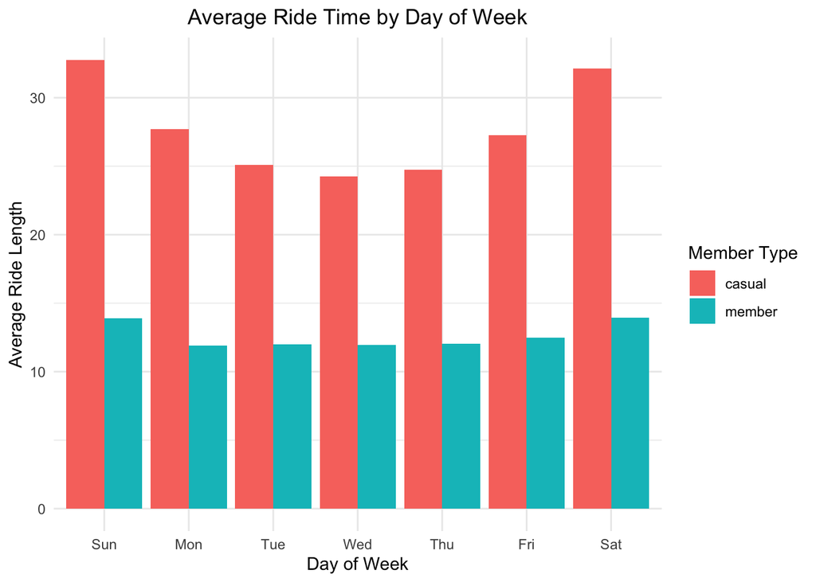

```r
# Create pivot table
pivot_avg_by_day <- data %>%
   group_by(member_casual, day_of_week) %>%
   summarize(average_ride_length = mean(ride_length, na.rm = TRUE) / 60, .groups = "keep")

# Remove NA as day of week
pivot_avg_by_day <- pivot_avg_by_day[!is.na(pivot_avg_by_day$day_of_week), ]

# Change the day_of_week column to display "Sun", "Mon", ..., "Sat"
pivot_avg_by_day$day_of_week <- factor(lubridate::wday(pivot_avg_by_day$day_of_week, label = TRUE), levels = c("Sun", "Mon", "Tue", "Wed", "Thu", "Fri", "Sat"))

# Create a bar graph using ggplot2
ggplot(pivot_avg_by_day, aes(x = day_of_week, y = average_ride_length, fill = member_casual)) +
   geom_col(position = "dodge") +
   ggtitle("Average Ride Time by Day of Week") +
   labs(x = "Day of Week", y = "Average Ride Length", fill = "Member Type") +
   theme_minimal() +
   theme(plot.title = element_text(hjust = 0.5))
```

Both casual riders and members tend to take the longest rides on Saturdays and Sundays. Members take shorter rides on average than casual riders, but the pattern of ride length by day of the week is similar for both groups.

#### 3. Average ride length by month - casual vs member rider

The graph below illustrates the average ride time for casual riders and members by month of the year.

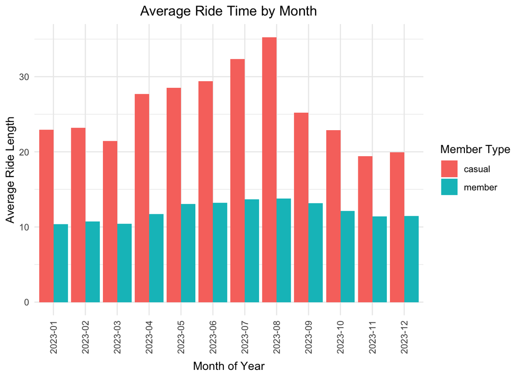

```r
# Create pivot table
pivot_avg_by_month <- data %>%
   group_by(member_casual, month_of_year) %>%
   summarize(average_ride_length = mean(ride_length, na.rm = TRUE) / 60, .groups = "keep")

# Remove NA as day of week
pivot_avg_by_month <- pivot_avg_by_month[!is.na(pivot_avg_by_month$month_of_year), ]

# Create a bar graph of average ride time per month using ggplot2
ggplot(pivot_avg_by_month, aes(x = month_of_year, y = average_ride_length, fill = member_casual)) +
   geom_col(position = "dodge") +
   ggtitle("Average Ride Time by Month") +
   labs(x = "Month of Year", y = "Average Ride Length", fill = "Member Type") +
   theme_minimal() +
   theme(
      axis.text.x = element_text(angle = 90, vjust = 0.5, hjust = 1),
      axis.title.x = element_text(vjust = -1)
   ) +
   theme(plot.title = element_text(hjust = 0.5))
```

#### 4. Ride Count by Day of the Week

```r
## Total Number of rides for users by day_of_week

# Create pivot table
pivot_user_count_by_day <- data %>%
   filter(!is.na(day_of_week)) %>%
   group_by(member_casual, day_of_week) %>%
   summarise(
      average_ride_length = mean(ride_length, na.rm = TRUE) / 60,
      num_rides = n()
   )
```

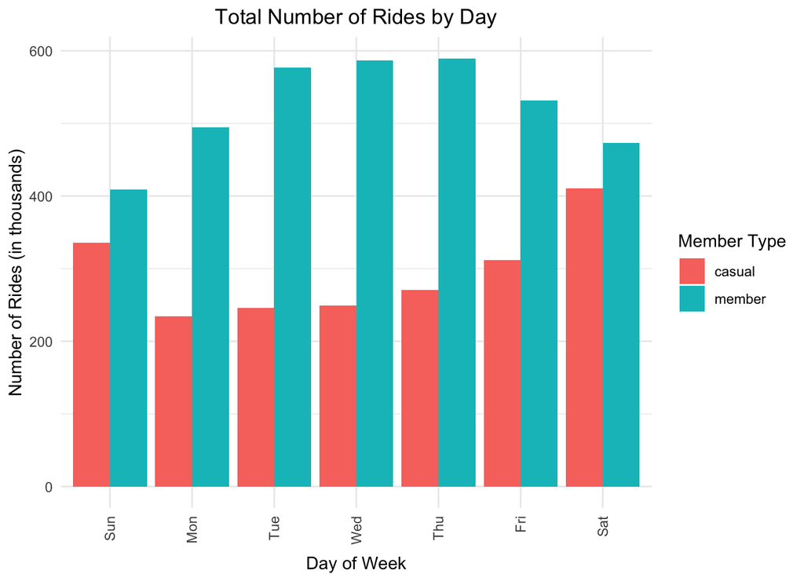

```r
# Remove NA as day of week
pivot_user_count_by_day <- pivot_user_count_by_day[!is.na(pivot_user_count_by_day$day_of_week), ]

# Change the day_of_week column to display "Sun", "Mon", ..., "Sat"
pivot_user_count_by_day$day_of_week <- lubridate::wday(pivot_user_count_by_day$day_of_week, label = TRUE)

# Create a bar graph of number of rides per month using ggplot2
# Note: use this to scale in units of 1,000: scale_y_continuous(labels = function(y) y / 1000)
ggplot(pivot_user_count_by_day, aes(x = day_of_week, y = num_rides, fill = member_casual)) +
   geom_col(position = "dodge") +
   ggtitle("Total Number of Rides by Day") +
   labs(x = "Day of Week", y = "Number of Rides (in thousands)", fill = "Member Type") +
   scale_y_continuous(labels = function(y) y / 1000) +
   theme_minimal() +
   theme(
      axis.text.x = element_text(angle = 90, vjust = 0.5, hjust = 1),
      axis.title.x = element_text(vjust = -1)
   ) +
   theme(plot.title = element_text(hjust = 0.5))
```

#### 5. Ride Count by Month

```r
## Avg ride lengths & Number of rides for users by day_of_week

# Create pivot table
pivot_user_count_by_month <- data %>%
   filter(!is.na(month_of_year)) %>%
   group_by(member_casual, month_of_year) %>%
   summarise(
      average_ride_length = mean(ride_length, na.rm = TRUE) / 60,
      num_rides = n()
   )
```

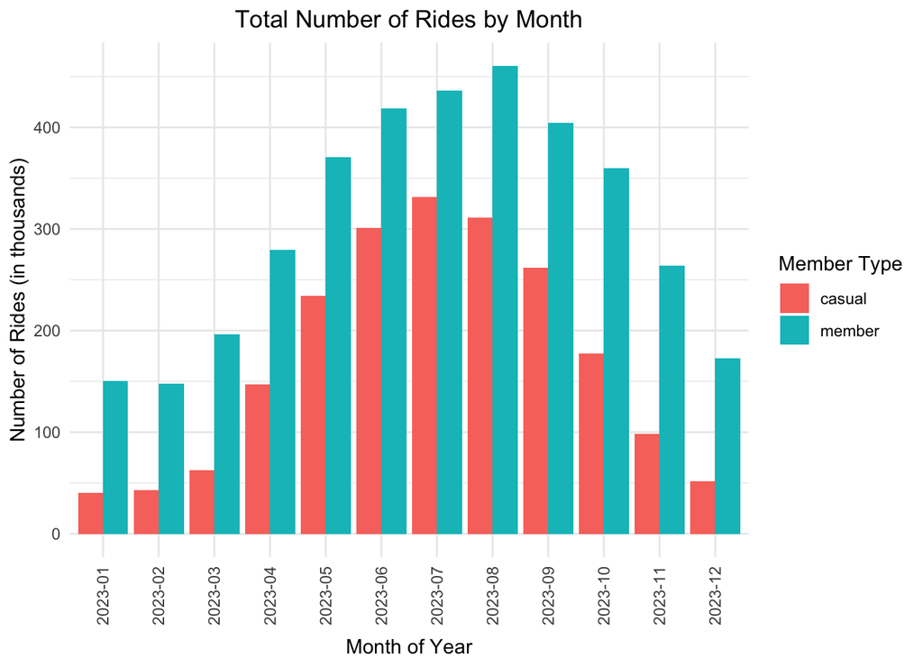

[output not shown]

```r
# Create a bar graph of number of rides per month using ggplot2
# Note: use this to scale in units of 1,000: scale_y_continuous(labels = function(y) y / 1000)
ggplot(pivot_user_count_by_month, aes(x = month_of_year, y = num_rides, fill = member_casual)) +
   geom_col(position = "dodge") +
   ggtitle("Total Number of Rides by Month") +
   labs(x = "Month of Year", y = "Number of Rides (in thousands)", fill = "Member Type") +
   scale_y_continuous(labels = function(y) y / 1000) +
   theme_minimal() +
   theme(
      axis.text.x = element_text(angle = 90, vjust = 0.5, hjust = 1),
      axis.title.x = element_text(vjust = -1)
   ) +
   theme(plot.title = element_text(hjust = 0.5))
```

#### 6. Bike Rental Type Analysis

Total Rentals by Bike Type

```r
# Create pivot table
pivot_bike_type <- data %>%
   filter(!is.na(rideable_type)) %>%
   group_by(member_casual, rideable_type) %>%
   summarise(
      num_rides = n()
   )
```

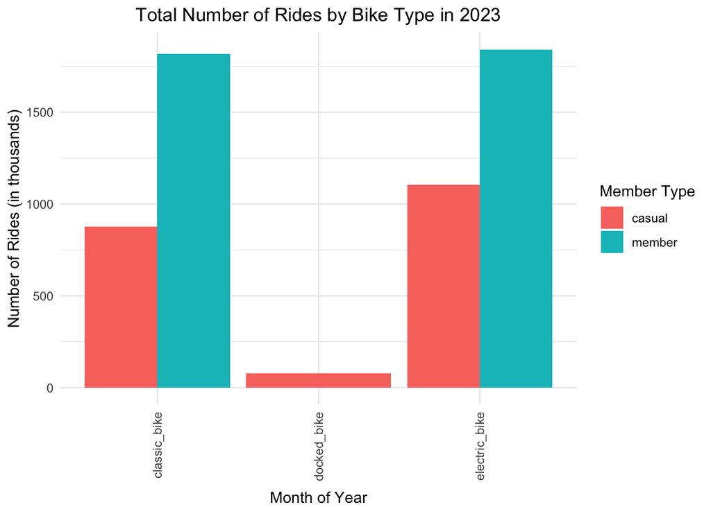

```r
# Create a bar graph of number of rides per month using ggplot2
# Note: use this to scale in units of 1,000: scale_y_continuous(labels = function(y) y / 1000)
ggplot(pivot_bike_type, aes(x = rideable_type, y = num_rides, fill = member_casual)) +
   geom_col(position = "dodge") +
   ggtitle("Total Number of Rides by Bike Type in 2023") +
   labs(x = "Month of Year", y = "Number of Rides (in thousands)", fill = "Member Type") +
   scale_y_continuous(labels = function(y) y / 1000) +
   theme_minimal() +
   theme(
      axis.text.x = element_text(angle = 90, vjust = 0.5, hjust = 1),
      axis.title.x = element_text(vjust = -1)
   ) +
   theme(plot.title = element_text(hjust = 0.5))
```

### Save my updated dataframe “data” to a csv file and RData file

I haven’t mastered using the Rdata file yet, so I’m going to save the data to a csv file as well.

```r
write.csv(data, file = "../data/2023_data_cyclistic.csv", row.names = FALSE) # file size-1.2 GB
save(data, file = "../data/2023_data_cyclistic.RData") # file size-189 MB
```

## Data Analysis Process Step 6 - Act

### Suggestions

- Propose incentives for casual riders during colder months to encourage them to use the bikes more frequently, as their total bike usage time tends to decrease during these months.
- Introduce incentives during the middle of the week to motivate casual riders to use the bikes more often, as they are typically less active during these days.
- Implement targeted marketing strategies for both casual riders and members during colder months when their service usage decreases. Although members tend to have consistent trip lengths regardless of the season, they take fewer trips during colder months.
- Given the high popularity of classic and electric bikes and the low demand for docked bikes, consider gradually phasing out the docked bikes.

## Additional Analysis

- If more data such as addresses or zip codes could be obtained, it would be possible to analyze usage patterns at a neighborhood level. This could enable more finely tuned marketing and incentive strategies by neighborhood, leading to more effective campaigns.
- Other demographic data like income levels, age, and gender would allow for a more detailed analysis and better recommendations. If such data becomes available, it should be incorporated into the analysis.
- Current pricing of fees paid by casual riders and annual members could also be useful in finding ways to convert casual riders into annual members.

## Presentation

The presentation of my findings can be found in this [slide deck](https://netorgft2723307-my.sharepoint.com/:p:/g/personal/bh_brianhafner_com/Eainj-2xZm9MsasW2MMNbXABJYyKDpGYMwoNxHjloHFivA?e=3fLEoS).

## Appendix

I use pandoc in MacOS to convert my OneNote notes to RMarkdown. I copied my OneNote notes to a Word doc and then used pandoc to convert the Word doc to RMarkdown.

```bash
#<!-- pandoc -o output.md project_notes.docx -->
```

## References

- [R Best Practices - Krista L. DeStasio, M.S](https://kdestasio.github.io/post/r_best_practices/)